# Power Analysis: Introduction

Slides: https://osf.io/t5rjf/

Felix Schönbrodt

felix.schoenbrodt@psy.lmu.de

Ludwig-Maximilians-Universität München

2024-04-19

# Part I: General concepts of power analysis

# What is statistical power?

## A 2x2 classification matrix

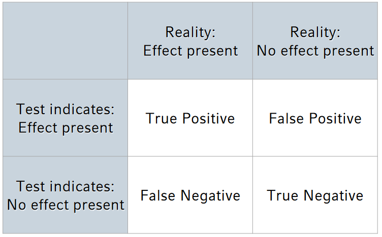

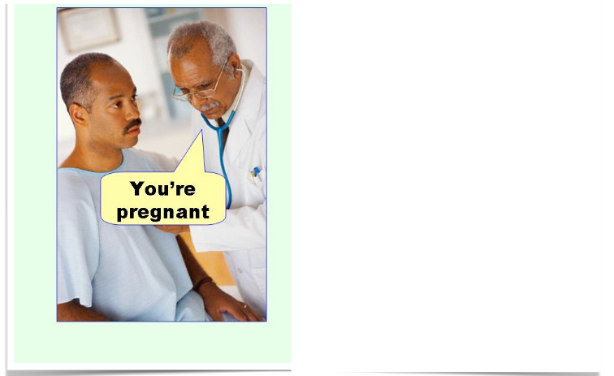

https://effectsizefaq.files.wordpress.com/2010/05/type-i-and-type-ii-errors.jpg

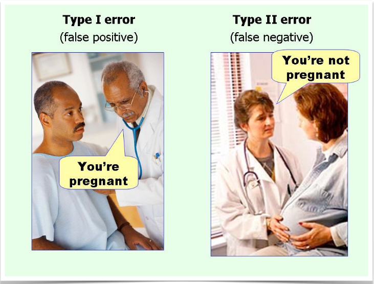

https://effectsizefaq.files.wordpress.com/2010/05/type-i-and-type-ii-errors.jpg

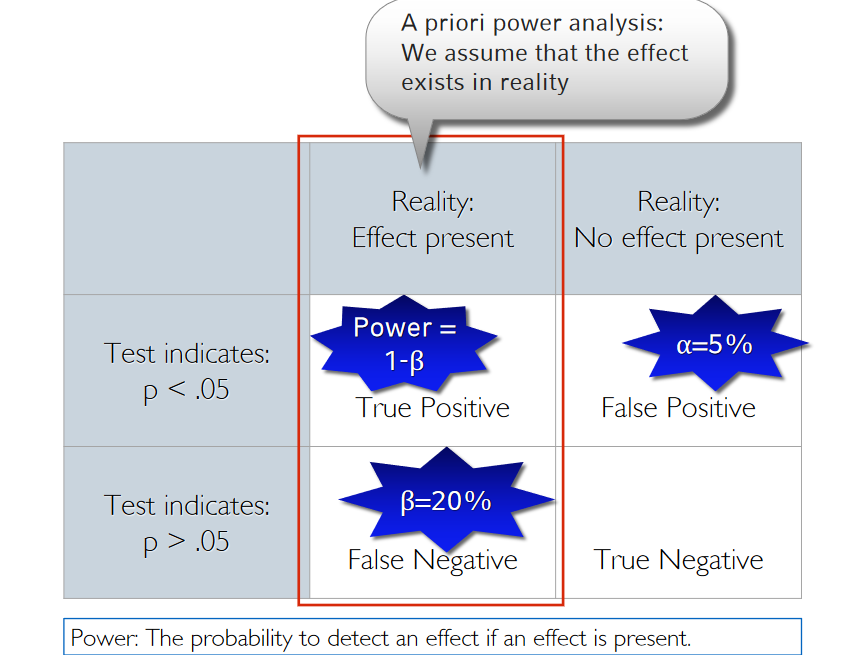

## How to do a power analysis

```
flowchart LR
    E[" Effect Size
    (see Part II of the workshop)"]
    D[" Desired Power
     usually 80%, 90% recommended for critical
studies (Bondavera, 2013)"]
    L[" Significance Level
    0.05? 0.005 (Benjamin et al., 2018)? justify
your alpha (Lakens et al., 2018)? "]
    S[Sample Size]
    L --> S
    D --> S
    E --> S
```

Benjamin et al. (2018). Redefine statistical significance. doi:10.1038/s41562-017-0189-z; Lakens et al. (2018). Justify your alpha. doi:[10.1038/s41562-018-0311-x](https://pure.tue.nl/ws/portalfiles/portal/119109470/Lakens_et_al._2018_Justify_your_alpha.pdf)

## Power is a frequentist property - beware of fallacies!

### Power is a pre-data measure (i.e., before data are collected) that averages over infinite hypothetical experiments

- Only one of these hypothetical experiments will actually be observed
- **Power is a property of the test procedure/ the design – not of a single study’s outcome!**

### Power is conditional on a hypothetical effect size – not conditional on the actual data obtained

- “Once the actual data are available, a power calculation is no longer conditioned on what is known, no longer corresponds to a valid inference, and may now be misleading.” ➙ for inference better use likelihood ratios or Bayes factors. Then pre-data power considerations are irrelevant.

Wagenmakers et al. (2014). A power fallacy. *Behavior Research Methods, 47*, 913–917. doi:10.3758/s13428-014-0517-4

## Post hoc power considerations

- Using the observed effect size to calculate “post hoc power” is meaningless (it‘s just a transformation of the p-value)
- It is however meaningful to estimate the power you have achieved with your collected sample size and the a priori assumed effect size (“sensitivity power analysis”)

https://daniellakens.blogspot.com/2014/12/observed-power-and-what-to-do-if-your.html Gelman, A. (2019). Don’t calculate post-hoc power using observed estimate of effect size. Ann. Surg, 269, e9-e10

# Why power is important

## Exercise:

Given that *p* < .05:  
What is the probability that a real effect exists in the population ➙ $p(H_1 | D)$?

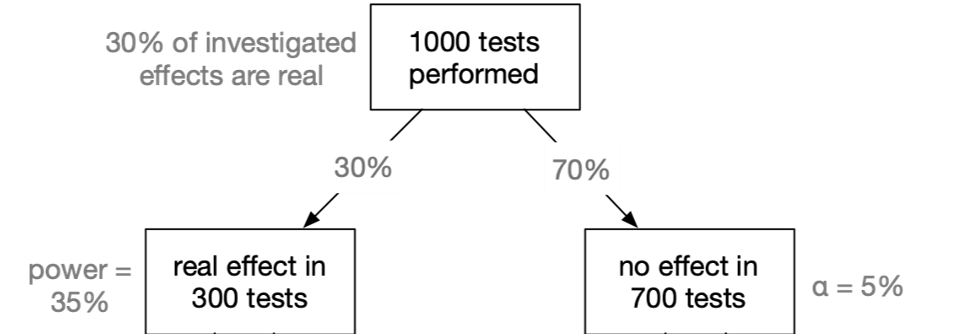

Nuzzo, R. (2014). Statistical errors. Nature. Colquhoun, D. (2014). An investigation of the false discovery rate and the misinterpretation of p-values. Royal Society Open Science, 1(3), 140216–140216. http://doi.org/10.1073/pnas.1313476110

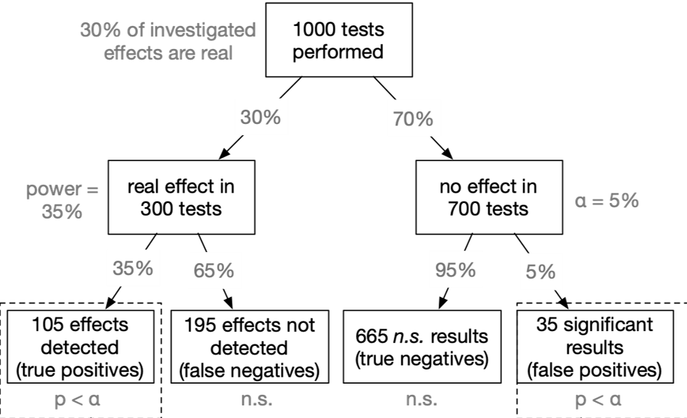

Nuzzo, R. (2014). Statistical errors. Nature. Colquhoun, D. (2014). An investigation of the false discovery rate and the misinterpretation of p-values. Royal Society Open Science, 1(3), 140216–140216. http://doi.org/10.1073/pnas.1313476110

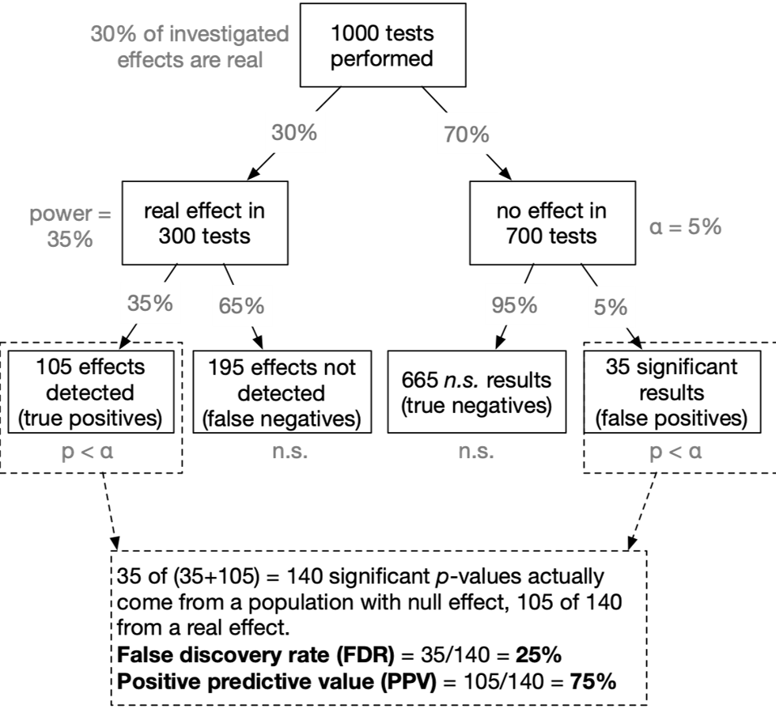

Nuzzo, R. (2014). Statistical errors. Nature. Colquhoun, D. (2014). An investigation of the false discovery rate and the misinterpretation of p-values. Royal Society Open Science, 1(3), 140216–140216. http://doi.org/10.1073/pnas.1313476110

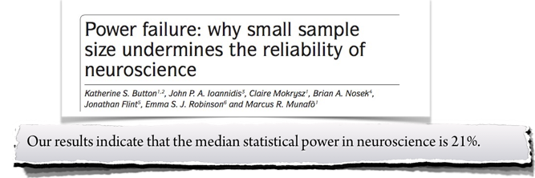

Assumed that our tested hypothesis are true in 30% of all cases (which is a not too risky research scenario):

- A typical neuroscience study must “fail” (*p* > $\alpha$) in 90% of all cases
- In the most likely outcome of *p* > .05, we have no idea whether a) the effect does not exist, or b) we simply missed the effect. Virtually no knowledge has been gained.

Button, K. S., Ioannidis, J. P. A., Mokrysz, C., Nosek, B. A., Flint, J., Robinson, E. S. J., & Munafò, M. R. (2013). Power failure: why small sample size undermines the reliability of neuroscience. Nat Rev Neurosci, 14(5), 365–376. doi:10.1038/nrn3475

> When a study is underpowered it most likely provides only weak inference. Even before a single participant is assessed, it is highly unlikely that an underpowered study provides an informative result.

> Consequently, research unlikely to produce diagnostic outcomes is inefficient and can even be considered unethical. Why sacrifice people’s time, animals’ lives, and societies’ resources on an experiment that is highly unlikely to be informative?

Schönbrodt, F. D. & Wagenmakers, E.-J. (2018). [Bayes Factor Design Analysis: Planning for compelling evidence](https://osf.io/d4dcu/). Psychonomic Bulletin & Review, 25, 128-142. doi:10.3758/s13423-017-1230-y

## A power analysis helps you to find a balance between…

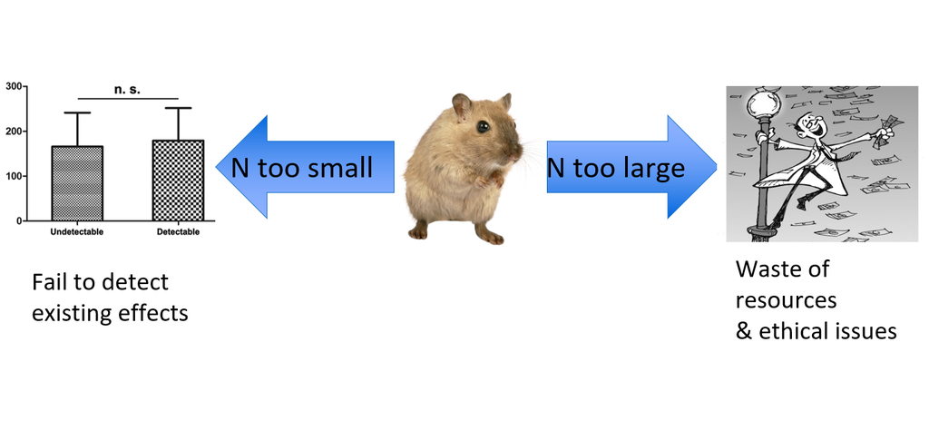

Pictures from nature.com/articles/srep43627, pngimg.com/download/23544, whyopenresearch.org/funding

# Researcher‘s intuitions about power

## Researcher’s intuitions about power

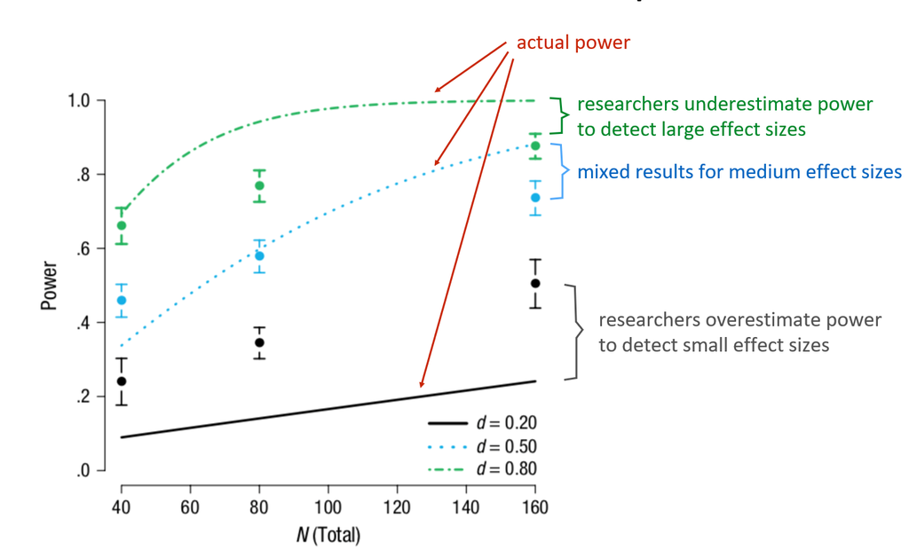

Bakker, M., Hartgerink, C. H. J., Wicherts, J. M., & van der Maas, H. L. J. (2016). Researchers’ Intuitions About Power in Psychological Research. Psychological Science, 27(8), 1069–1077. http://doi.org/10.1177/0956797616647519

## Calibrate your power feeling

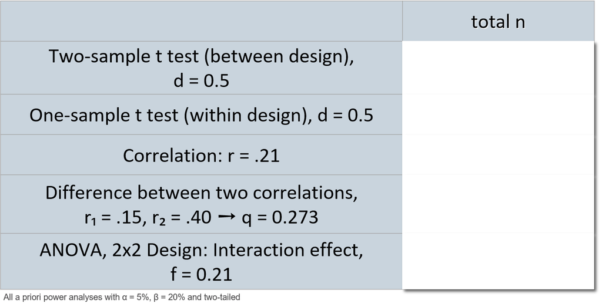

## Calibrate your power feeling

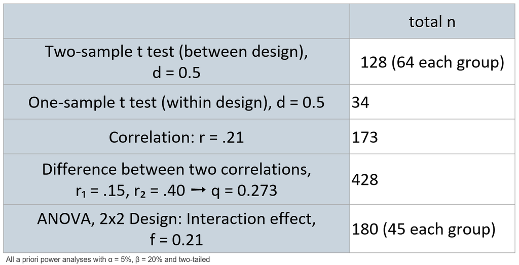

# Clever designs go a long way

## The power of within-SS designs

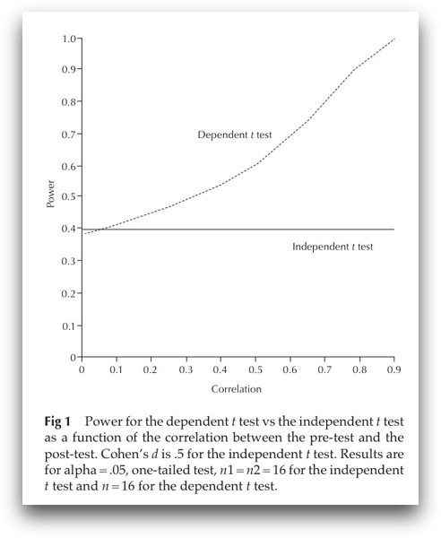

- Why? Each person is his/her own control group
- For example, for the paired t-test:
  - By computing the within-person difference scores, all between-person variance (which contributes to error variance), gets removed
  - Less error variance → less noise → (relatively) more signal → larger effect size

## Increase power with reliable measures

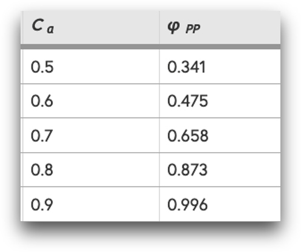

- Cohen’s d = 0.4
- N = 30
- pre-post-test

Heo, M., Kim, N., & Faith, M. S. (2015). Statistical power as a function of Cronbach alpha of instrument questionnaire items. BMC Medical Research Methodology, 15. doi:10.1186/s12874-015-0070-6

## Specific predictions? Use one-tailed tests!

- One-tailed tests have a higher power than two-tailed tests
- Particularly recommended in combination with a preregistration
- Most power analysis approaches (G*Power, R packages) allow you to chose between one- and two-tailed tests

# Any questions so far?

# Part II: Effect sizes / smallest effects of interests

# Common effect size metrics

## Common effect sizes

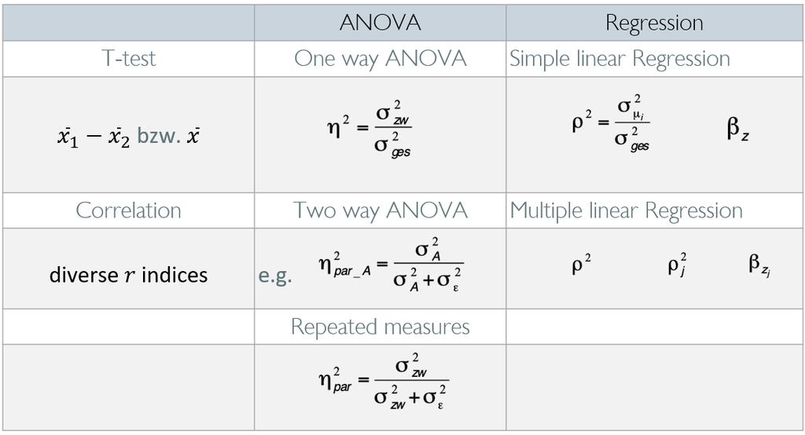

## Effect size transformations

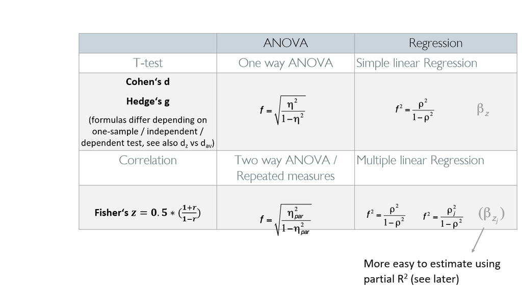

## Effect size transformations

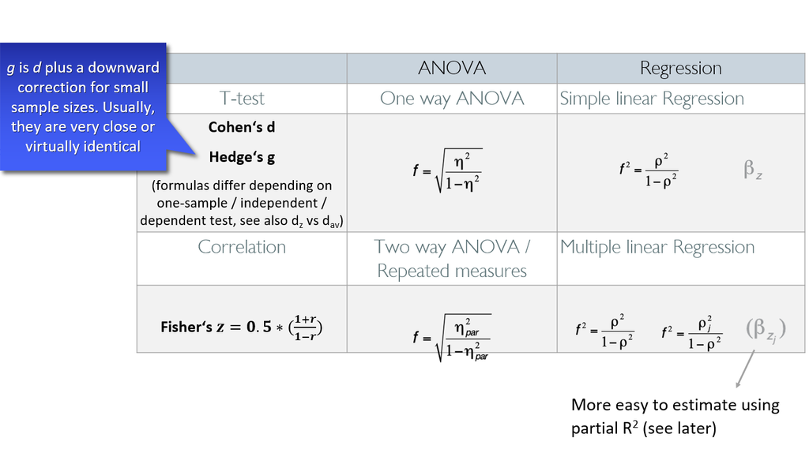

Borenstein, M., Hedges, L. V., Higgins, J. P. T., & Rothstein, H. R. (2009). Effect sizes based on correlations. In Introduction to Meta-Analysis, p. 45-49. Brysbaert, M. (2019) How Many Participants Do We Have to Include in Properly Powered Experiments? A Tutorial of Power Analysis with Reference Tables. Journal of Cognition, 2(1): 16, pp. 1–38. DOI: https://doi.org/10.5334/joc.72 Lakens, D. (2013). Calculating and reporting effect sizes to facilitate cumulative science: A practical primer for t-tests and ANOVAs. Frontiers in Psychology, 4. https://doi.org/10.3389/fpsyg.2013.00863

## Converting among effect sizes

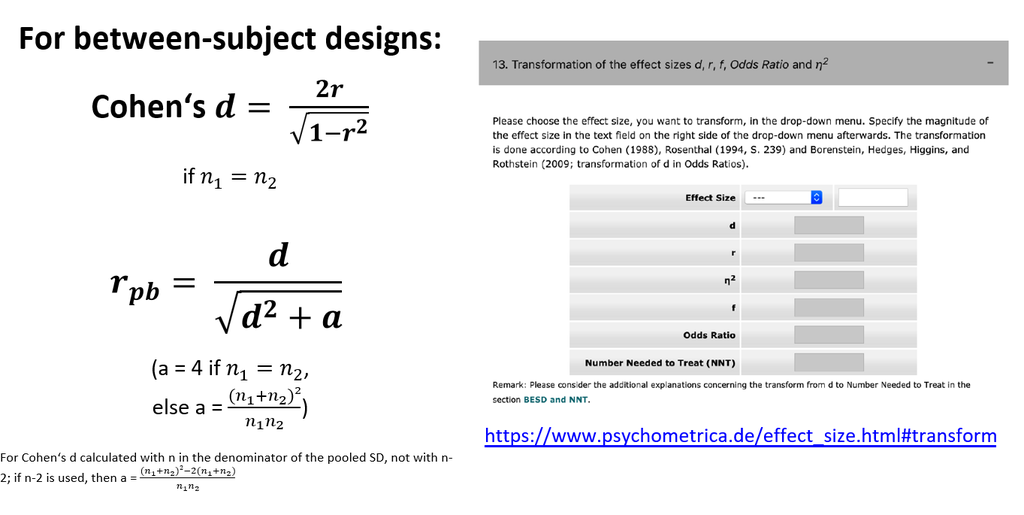

Borenstein, M., Hedges, L. V., Higgins, J. P. T., & Rothstein, H. R. (2009). Converting among effect sizes. In Introduction to Meta-Analysis, p. 45-49. Lakens, D. (2013). Calculating and reporting effect sizes to facilitate cumulative science: A practical primer for t-tests and ANOVAs. Frontiers in Psychology, 4. https://doi.org/10.3389/fpsyg.2013.00863

## Converting among effect sizes

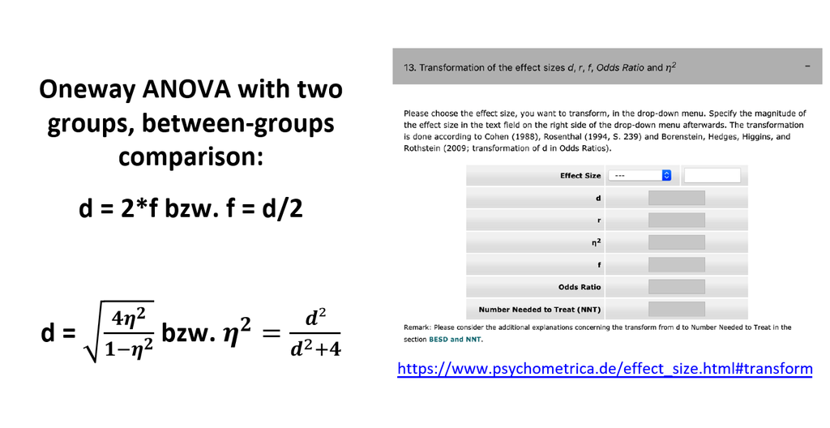

https://www.ibm.com/support/pages/effect-size-relationship-between-partial-eta-squared-cohens-f-and-cohens-d Brysbaert, M. (2019) How Many Participants Do We Have to Include in Properly Powered Experiments? A Tutorial of Power Analysis with Reference Tables. Journal of Cognition, 2(1): 16, pp. 1–38. DOI: https://doi.org/10.5334/joc.72

## Converting among effect sizes

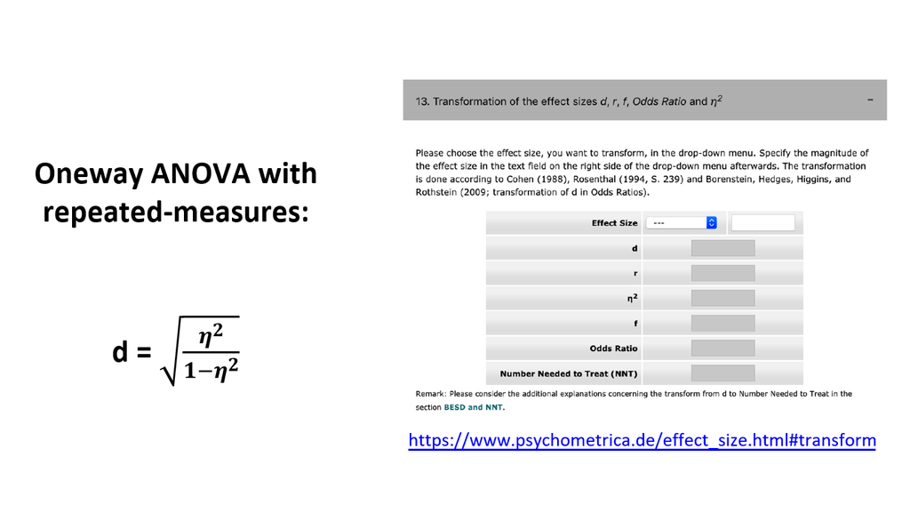

Brysbaert, M. (2019) How Many Participants Do We Have to Include in Properly Powered Experiments? A Tutorial of Power Analysis with Reference Tables. Journal of Cognition, 2(1): 16, pp. 1–38. DOI: https://doi.org/10.5334/joc.72

## Converting among effect sizes

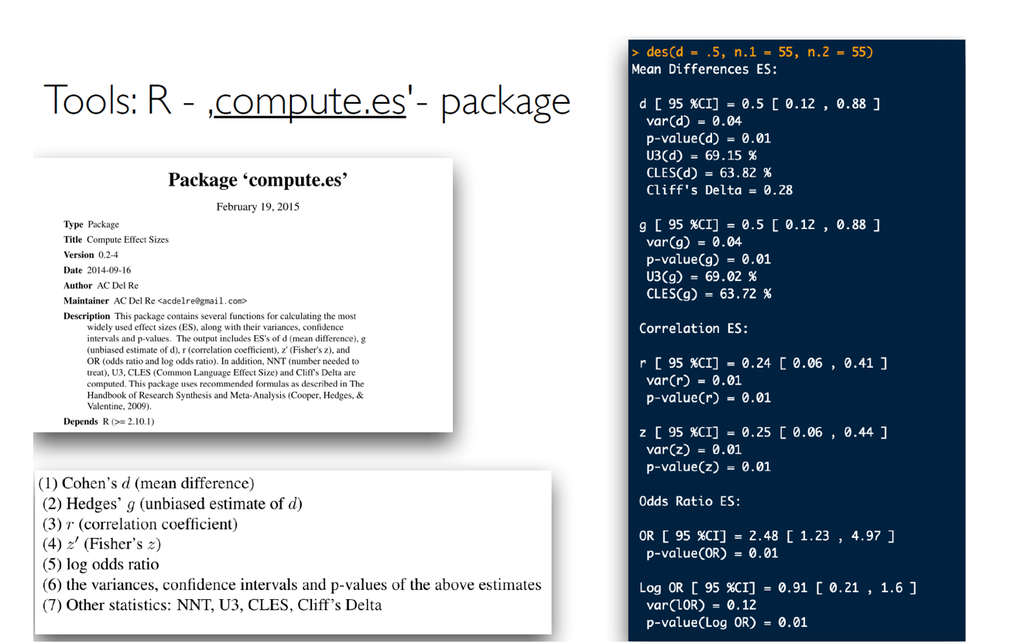

# Getting a feeling about effect sizes

## How do these effect sizes look like?

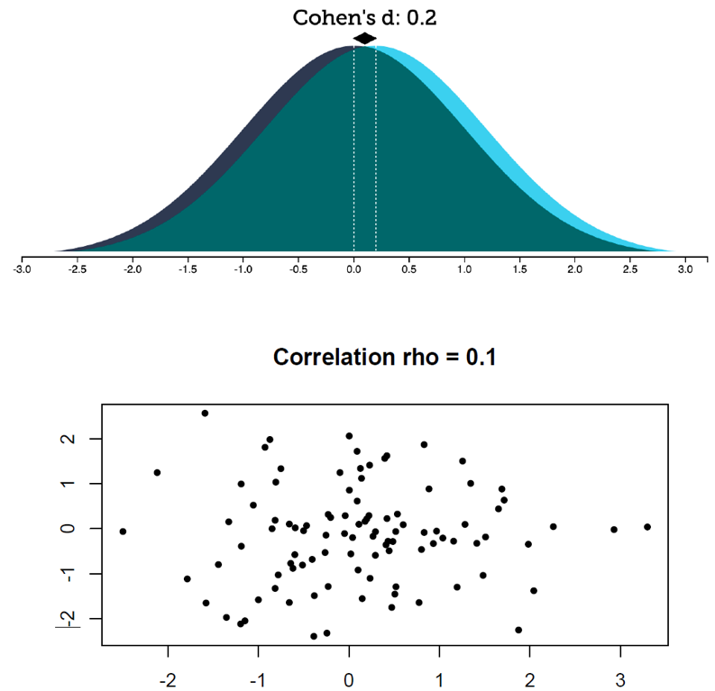

https://rpsychologist.com/d3/cohend/

## How do these effect sizes look like?

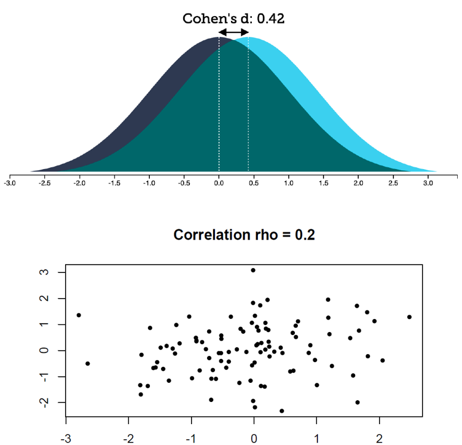

https://rpsychologist.com/d3/cohend/

## How do these effect sizes look like?

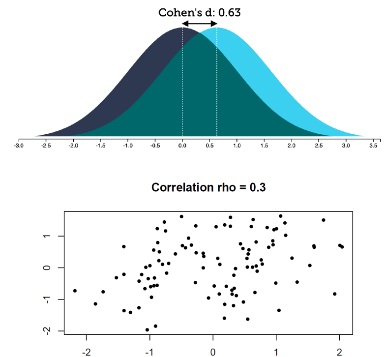

https://rpsychologist.com/d3/cohend/

## Guess the correlation

[figure not shown]

http://guessthecorrelation.com/

## Guess the correlation

[figure not shown]

http://guessthecorrelation.com/

## Understanding effect sizes

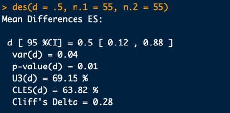

More understandable metrics: „Common Language Effect Size“, CLES:

- …the probability that a randomly sampled person from one group will have a higher observed measurement than a randomly sampled person from the other group (for between designs)
- …or (for within-designs) the probability that an individual has a higher value on one measurement than the other.

McGraw & Wong (1992). A common language effect size statistic. https://doi.org/10.1037/0033-2909.111.2.361

## Understanding effect sizes

# Typical effect sizes

## Cohen‘s conventions

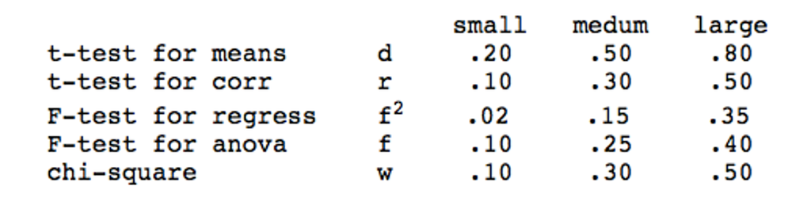

Is this reasonable?

## Typical reported effect sizes I

### Richard, Bond, & Stokes-Zoota (2003), correlation metric

- Meta-meta-analysis; > 25.000 studies, > 8.000.000 participants
- mean effect *r* = .21 (across literature *SD* = .15); median = .18

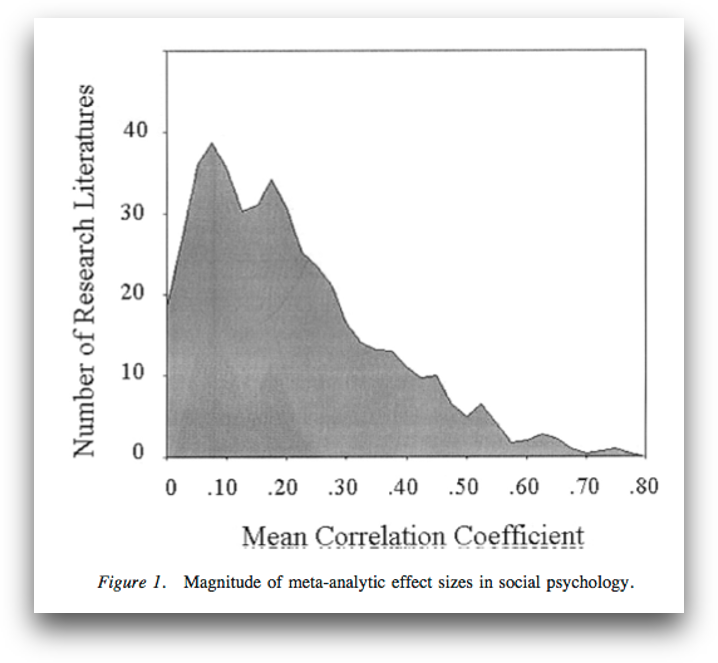

Richard, F. D., Bond, C. F. J., & Stokes-Zoota, J. J. (2003). One Hundred Years of Social Psychology Quantitatively Described. Review of General Psychology, 7(4), 331–363. doi:10.1037/1089-2680.7.4.331

## Typical reported effect sizes I

### Richard, Bond, & Stokes-Zoota (2003), correlation metric

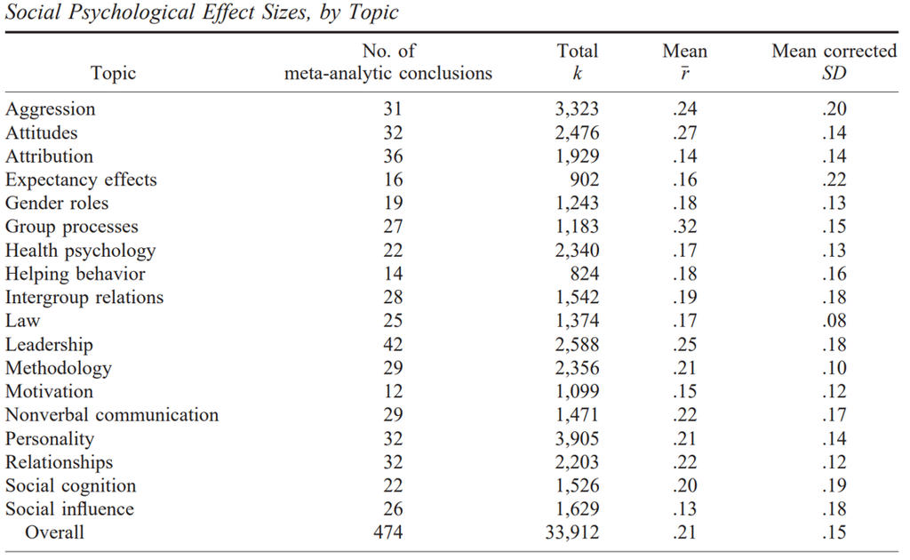